# Part II - (Investigation of Prosper Loan Data)

## by (Oluwatobiloba Oshinuga)

## Investigation Overview

In this investigations, I will be looking at different factors that influences the Loan status outcome, Borrowers rate, and Lenders yield and how these factors acts as criterias that determines the size of the Loan amount each borrowers qualifies for.

## Dataset Overview

This data set contains 113,937 loans with 81 variables on each loan, including loan amount, borrower rate (or interest rate), current loan status, borrower income, and many others.

## Distribution of Borrower Rate

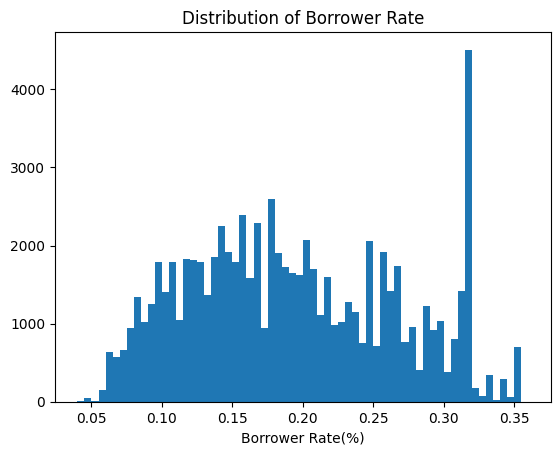

## Distribution of Listing Category

Majority of the borrowers took loans for Debt consolidation. Only few borrowers took loans for business or medicals which are 4.7% and 1.8% respectively.

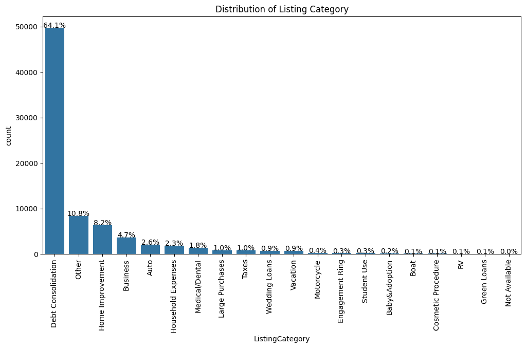

## Effect of Borrower Rate and Prosper Score on Loan Status Outcome

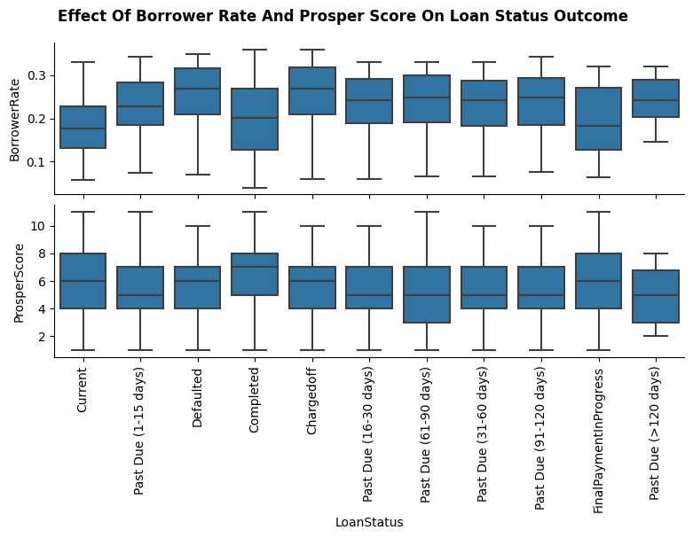

## Effect of Prosper Score, Credit Score on Borrowers Rate

Borrowers with high ProsperScore and CreditScore have a lower Interest or Borrower Rate on their Loans. The higher the ProsperScore and CreditScore the lower the BorrowerRate.

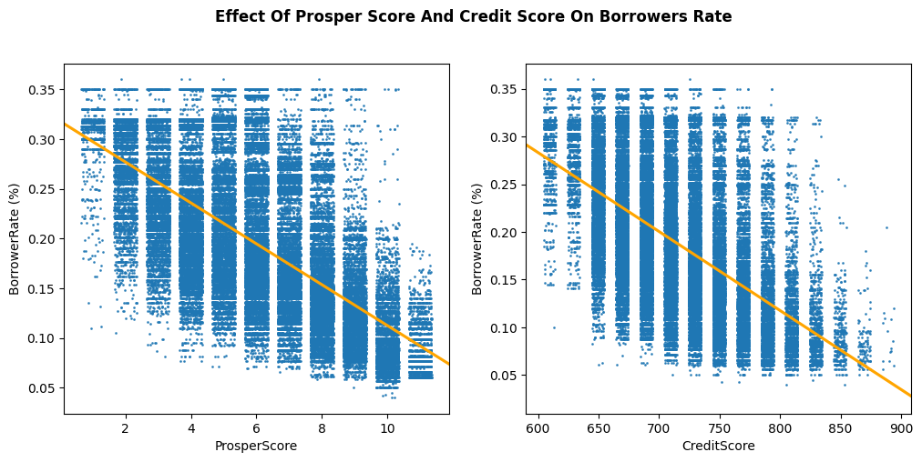

## Effect of Prosper Rating on the Loan Amount

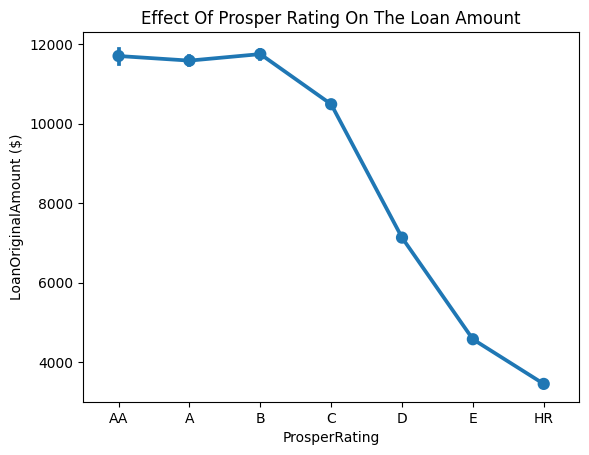

## Effect of ProsperScore and CreditScore on BorrowerRate

The higher the Prosper Score and the Credit Score the lower the BorrowerRate.

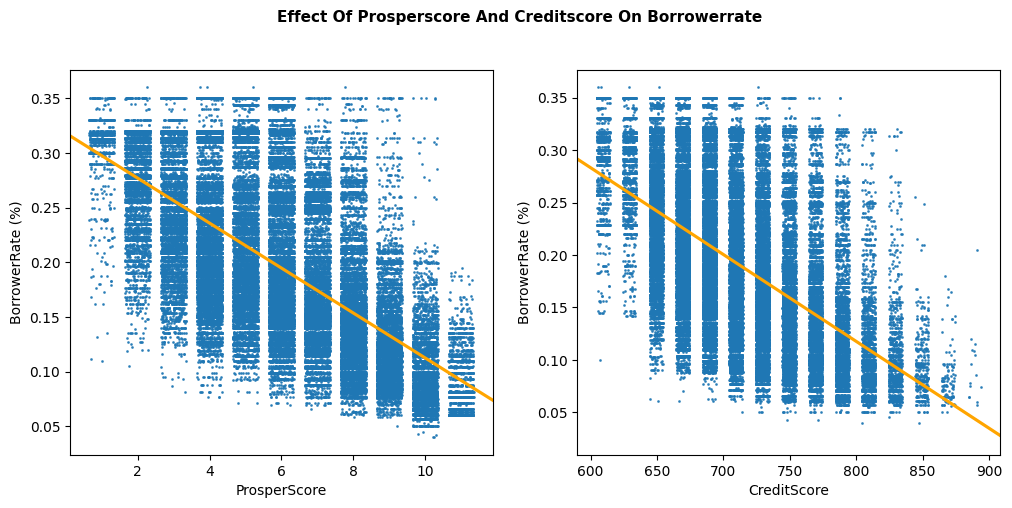

## Effect of ProsperRating on Loan Amount, BorrowerRate and LenderYield

Loan Amount reduces as Prosper Rating reduce from AA to HR. The higher the Prosper Rating the lower the Borrowers Rate and Lenders Yield. Borrowers with High Prosper Rating acquired larger loan amount and resulted in lesser yield to Lenders because of their lower Borrower Rate.

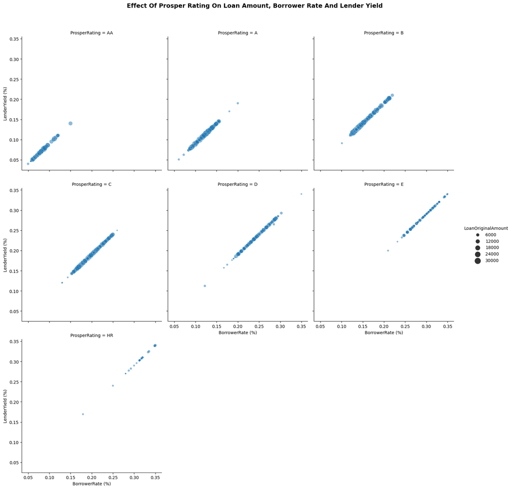

## Effect of Borrower Rate and Lender Yield on Estimated Loss

Loans with high Borrower Rate and Lender Yield incured the highest Loss. The higher the Borrower Rate and Lender Yield on each loans the higher the chances of the loan resulting in a loss.

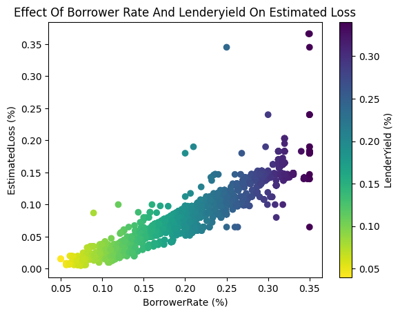